# Exploratory Data Analysis

Adriel Martins

4/19/2021

# Objetivo

1. Construa uma análise descritiva extraindo conhecimento das variáveis e apresentando quais insights podem ser obtidos a partir delas;
2. Construa graficamente um storytelling a partir das variáveis apresentadas no problema;
3. Descreva o caminho escolhido para sua EDA;
4. Descreva quais outras técnicas poderiam ser aplicadass e porquê você não as escolheu;
5. Utilize os dados: eda_data.zip

# Lendo os Dados

```
## # A tibble: 6 x 11
##   directions   fat date    categories calories desc       protein rating title
##   <list>     <dbl> <chr>   <list>        <dbl> <chr>        <dbl>  <dbl> <chr>
## 1 <chr [3]>      7 2006-0… <chr [11]>      426 <NA>            30   2.5  "Lenti…
## 2 <chr [5]>     23 2004-0… <chr [11]>      403 This uses…      18   4.38 "Boudi…
## 3 <chr [2]>      7 2004-0… <chr [7]>       165 <NA>             6   3.75 "Potat…
## 4 <chr [2]>     NA 2009-0… <chr [17]>       NA The Sicil…      NA   5    "Mahi-…
## 5 <chr [1]>     32 2004-0… <chr [11]>      547 <NA>            20   3.12 "Spina…
## 6 <chr [3]>     79 2004-0… <chr [10]>      948 This reci…      19   4.38 "The B…
## # … with 2 more variables: ingredients <list>, sodium <dbl>
```

Data summary

| Name | df |
| --- | --- |
| Number of rows | 20130 |
| Number of columns | 11 |
| _______________________ |  |
| Column type frequency: |  |
| character | 3 |
| list | 3 |
| numeric | 5 |
| ________________________ |  |
| Group variables | None |

**Variable type: character**

| skim_variable | n_missing | complete_rate | min | max | empty | n_unique | whitespace |
| --- | --- | --- | --- | --- | --- | --- | --- |
| date | 19 | 1.00 | 24 | 24 | 0 | 4110 | 0 |
| desc | 6635 | 0.67 | 4 | 1738 | 0 | 11081 | 0 |
| title | 19 | 1.00 | 4 | 113 | 0 | 17775 | 0 |

**Variable type: list**

| skim_variable | n_missing | complete_rate | n_unique | min_length | max_length |
| --- | --- | --- | --- | --- | --- |
| directions | 0 | 1 | 18099 | 0 | 24 |
| categories | 0 | 1 | 18178 | 0 | 37 |
| ingredients | 0 | 1 | 18191 | 0 | 51 |

**Variable type: numeric**

| skim_variable | n_missing | complete_rate | mean | sd | p0 | p25 | p50 | p75 | p100 | hist |
| --- | --- | --- | --- | --- | --- | --- | --- | --- | --- | --- |
| fat | 4222 | 0.79 | 346.10 | 20431.02 | 0 | 7.00 | 17.00 | 33.00 | 1722763 | ▇▁▁▁▁ |
| calories | 4154 | 0.79 | 6307.86 | 358585.12 | 0 | 198.00 | 331.00 | 586.00 | 30111218 | ▇▁▁▁▁ |
| protein | 4201 | 0.79 | 99.95 | 3835.62 | 0 | 3.00 | 8.00 | 27.00 | 236489 | ▇▁▁▁▁ |
| rating | 30 | 1.00 | 3.71 | 1.34 | 0 | 3.75 | 4.38 | 4.38 | 5 | ▂▁▁▅▇ |
| sodium | 4156 | 0.79 | 6211.47 | 332890.25 | 0 | 80.00 | 294.00 | 711.00 | 27675110 | ▇▁▁▁▁ |

Vemos que não há variável ou coluna inútil, com número muito alto de missing, sendo assim, procederemos sem ignorar nenhuma coluna.

Inicialmente, fazendo um rápido dicionário dos dados e seus significados, temos que:

- directions: são as instruções da receita;
- fat: quantidade de gordura;
- date: é a data que essa receita foi catalogada.
- categories: as categorias que essa receita se encaixa.
- calories: quantidade de calorias presente.
- desc: a descrição mais detalhada da receita.
- protein: a quantidade de proteína.
- rating: a avaliação daquela receita numa determinada plataforma.
- title: o título daquela receita.
- ingredientes: os ingredientes utilizados para fazer aquela receita.
- sodium: quantidade de sódio na receita.

# Limpando os dados

Em respeito as variáveis númericas fat, protein, etc.. Suspeitamos de valores extremos por conta da disparidade de valores entre os terceiro e quarto quartil. Notamos que o valor verdadeiramente explode.

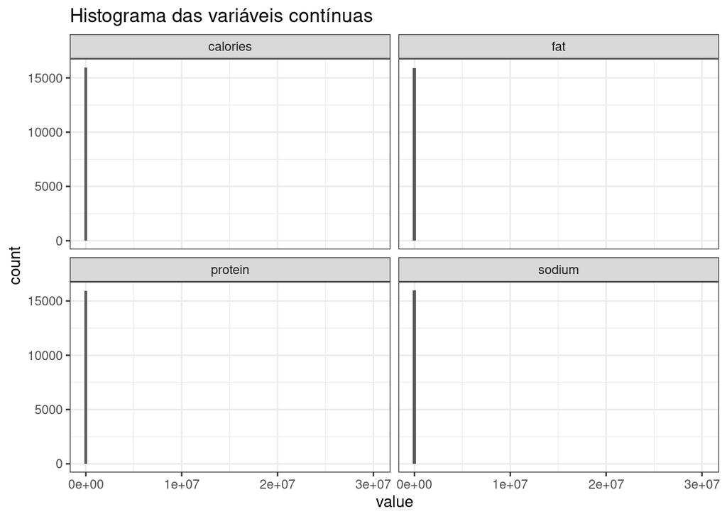

No gráfico acima, percebemos que ao montarmos um histograma considerando 100 espaços equi-espaçados, vemos que só conseguimos contar valores que cairám em um espaço basicamente. Ou seja, o quarto quartil está de fato muito distante dos demais.

Iremos realizar a limpeza deste dados ao considerarmos somente os valores abaixo do quantil de 95%. Pois, ao retirarmos tão poucos dados ainda conseguimos obter os insights das variáveis.

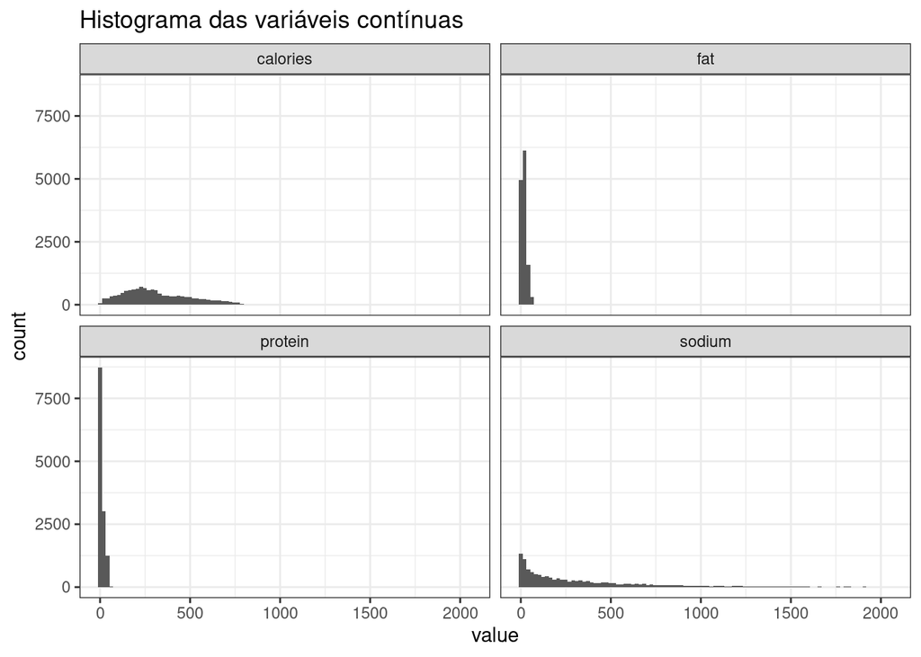

# Perguntas e Respostas

O formato de exploração dos dados escolhidos é o estilo pergunta e respostas. Inicialmente, traçamos algumas perguntas e tentamos obter a resposta através de análises gráficas, em especial, dos dados.

# Pergunta 1: O que faz um bom rating?

## Variável Rating

Para responder esta pergunta, comecemos com o questionamento de como é que está a quantidade dos ratings distribuídas.

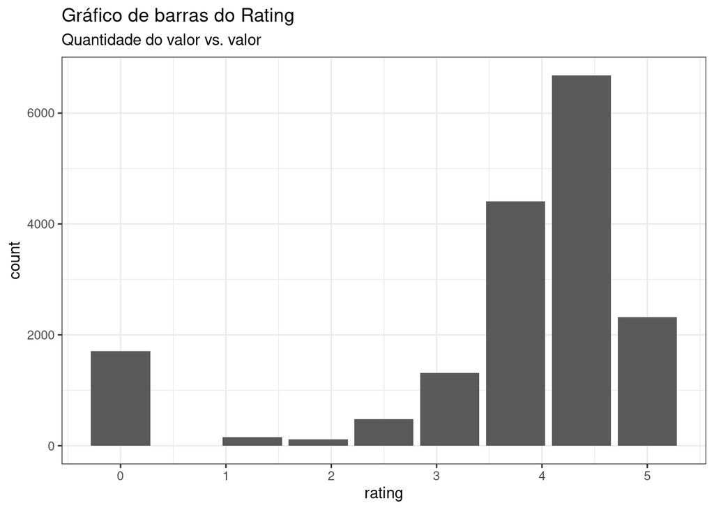

Vemos que poucas pessoas dão notas maiores que 0 e menores que 3. Sendo assim, podemos fazer nossa hipótese que se um serviço é menor que 3 estrelas, as pessoas tendem a colocar a nota 0. Além disso, notamos como há poucos valores únicos: há 8 valores. **Isto transforma o caráter contínuo da variável rating que poderia variar livremente entre 0 e 5, em basicamente, uma variável discreta.**

## Fat, sodium, protein, etc..

Voltando ao foco de nossa pergunta. Temos algumas variáveis explicativas em relação a nossa variável que queremos entender melhor: rating.

Comecemos querendo entender como essa variável se comporta, em relação aos elementos *fat, protein, sodium, protein, calories*. Pois, são elementos que o público, em geral, procura saber nas receitas pelas dietas específicas que restringem a quantidade de algum ou todos estes elementos.

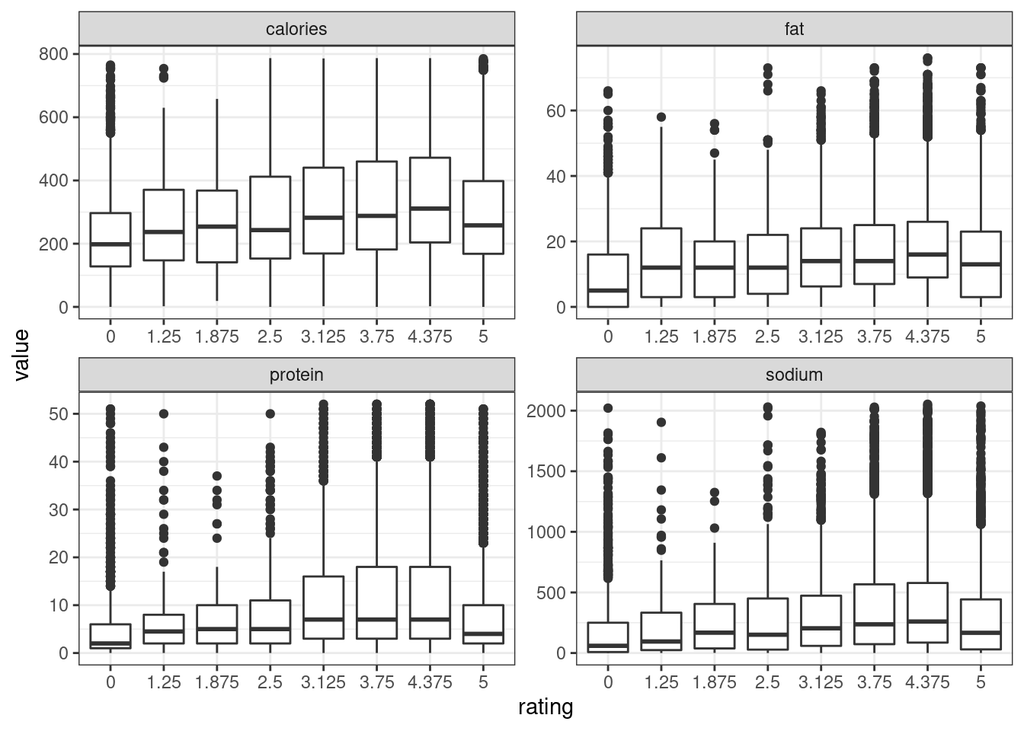

Podemos notar alguns padrões, porém não tão relevantes. Vemos que em geral, se há um aumento desses elementos, há também um aumento do rating. Contudo, em relação ao ratings com nota 5, vemos que eles sempre tem quantidades moderadas de todos estes elementos.

## Ingredientes

Vejamos o impacto dos ingredientes/modo de preparo tem na variável de rating.

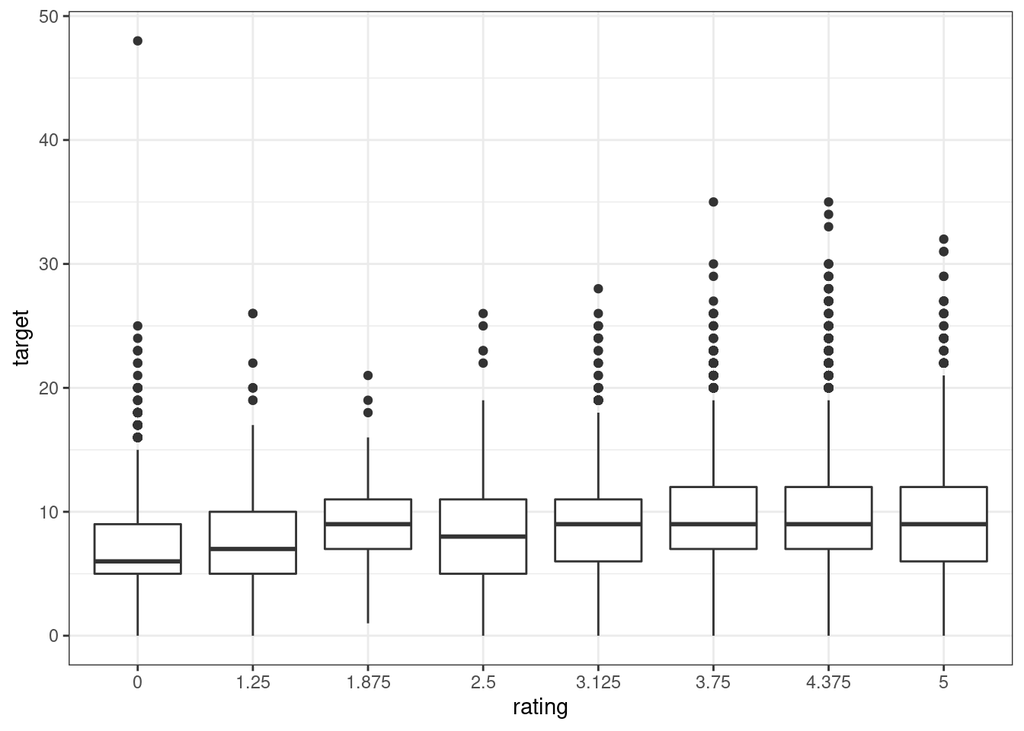

Vemos que a quantidade de ingredientes não faz muita diferença na variável rating.

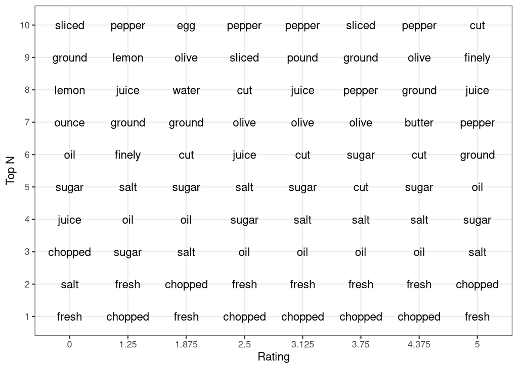

Vemos que os top 10 entre os ratings tem uma concordância entre si também. Comidas frescas, com sal, açucar, contendo óleo, etc.

## Categorias

Agora, vejamos o impacto das categorias no rating.

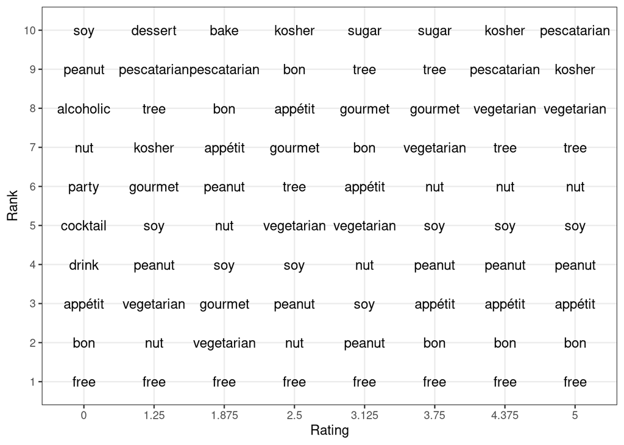

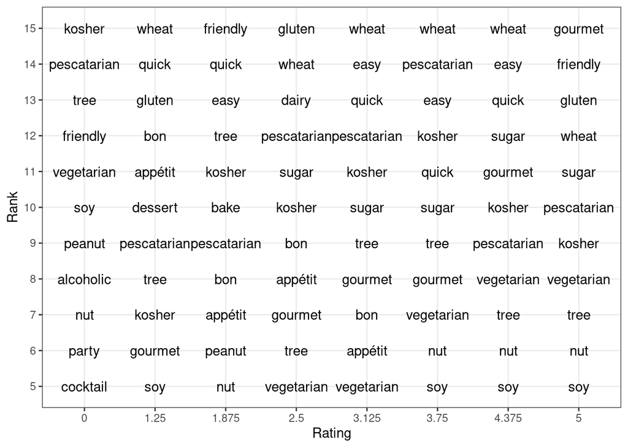

Há alguns insights interessantes aqui. Comentaremos sobre as categorias “vegetarian”, “kosher” e “pescatarian”:

1. Vemos que os ratings 2.5 e 3.125 tiveream uma preferência maior por “vegetarian”, isso indica que comidas vegetarianas tem uma maior dificuldade em agradar perfeitamente, pois onde no rating 5 e 4.375 temos que comidas vegetarianas obtiveram um rank número 8, sendo mais raro do que o rank número 5.

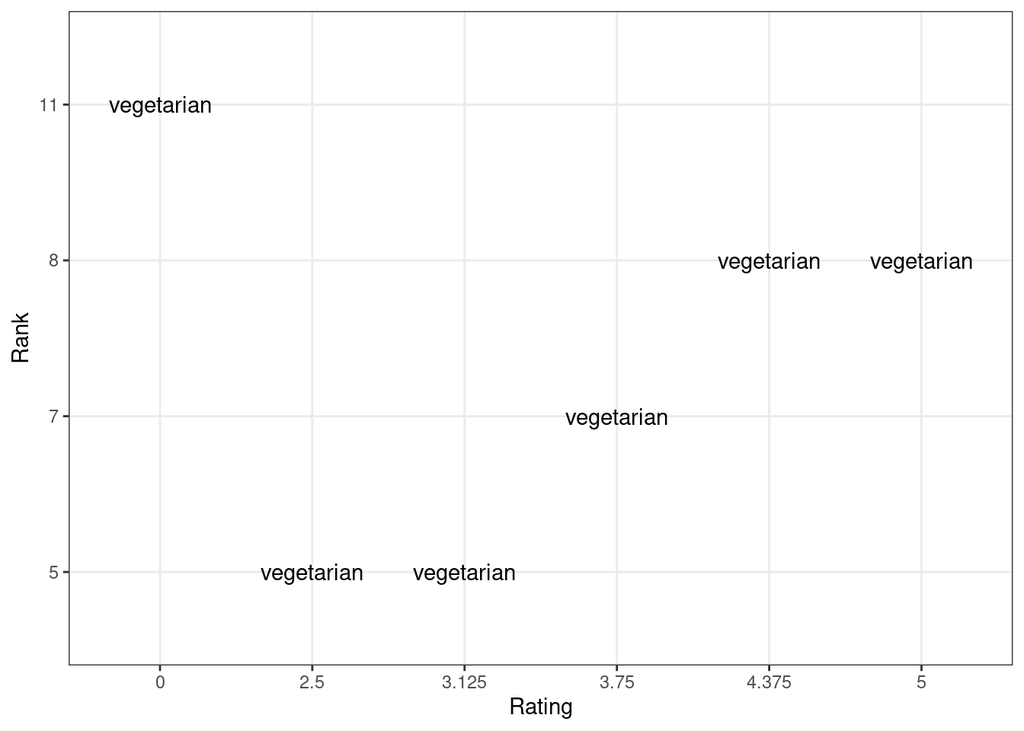

2. Comidas Kosher (comidas permitidas segundo as tradições judaicas), embora estivessem nas top 10 categorias do Rating 5 e 4.375, também ficaram nas top 10 do rating 1.25. Curiosamente, não ficaram também no top 10 do rating 0. Além de permanecerem no top 15 de todos os ratings.

Isto indica que comidas Kosher, mesmo sendo bastante peculiares, são muito populares e existe a possibilidade de fazer excelente comidas Kosher e péssimas comidas Kosher.

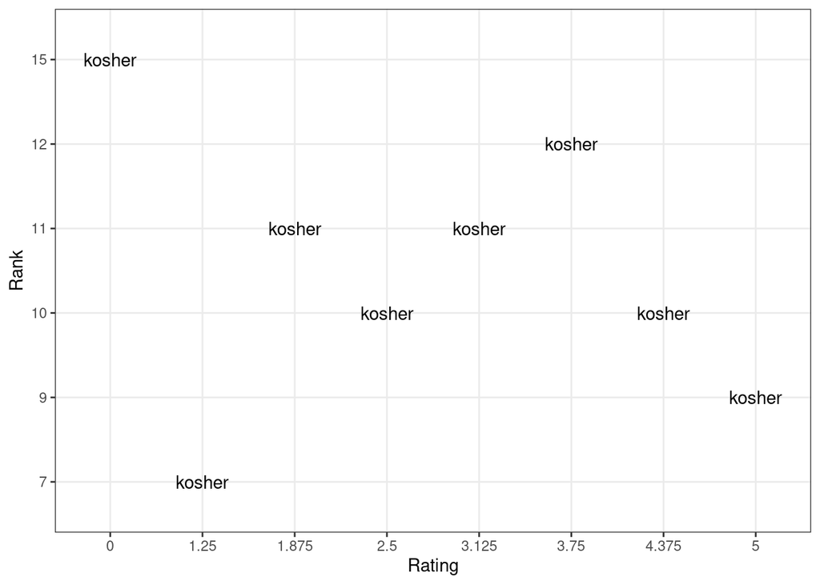

3. Similarmente a comidas Kosher, vemos essa variância em relação a distribuição de “pescatarian” (comidas que só tem peixe) perante os ratings. Embora sejam bastante populares estão no top 15 de todos os ratings, vemos que há muitos que classificam comidas “pescatarian” com o ranking acima de 4 e muitos que colocam entre 1.5 e 2, o que pode nos indicar que comidas com peixe tem uma sensibilidade maior. Ou seja, ou você acerta ou você erra bastante.

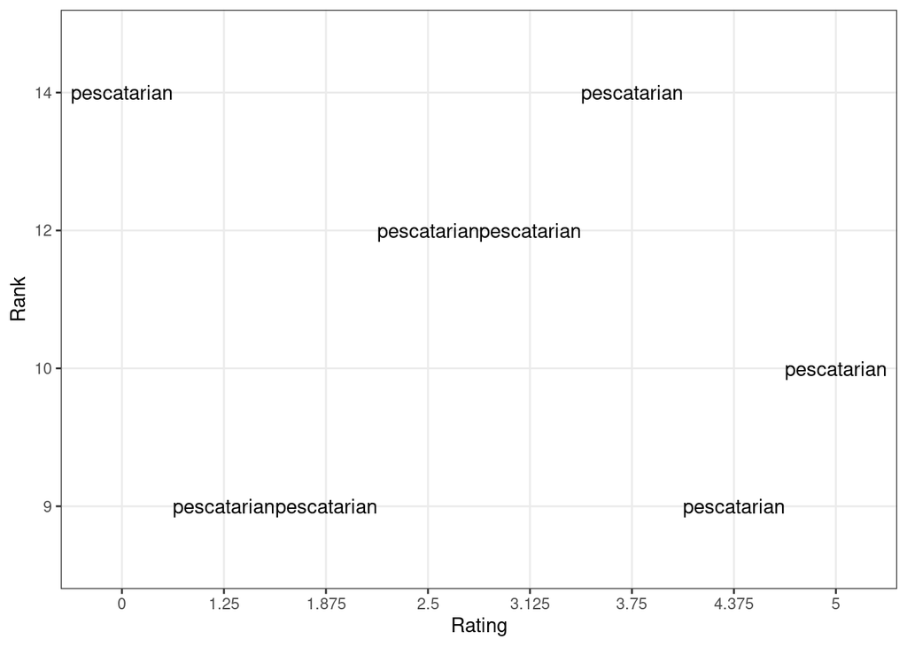

## Instruções (directions)

Vejamos aqui o impacto da quantidade de direções em ditar um bom rating.

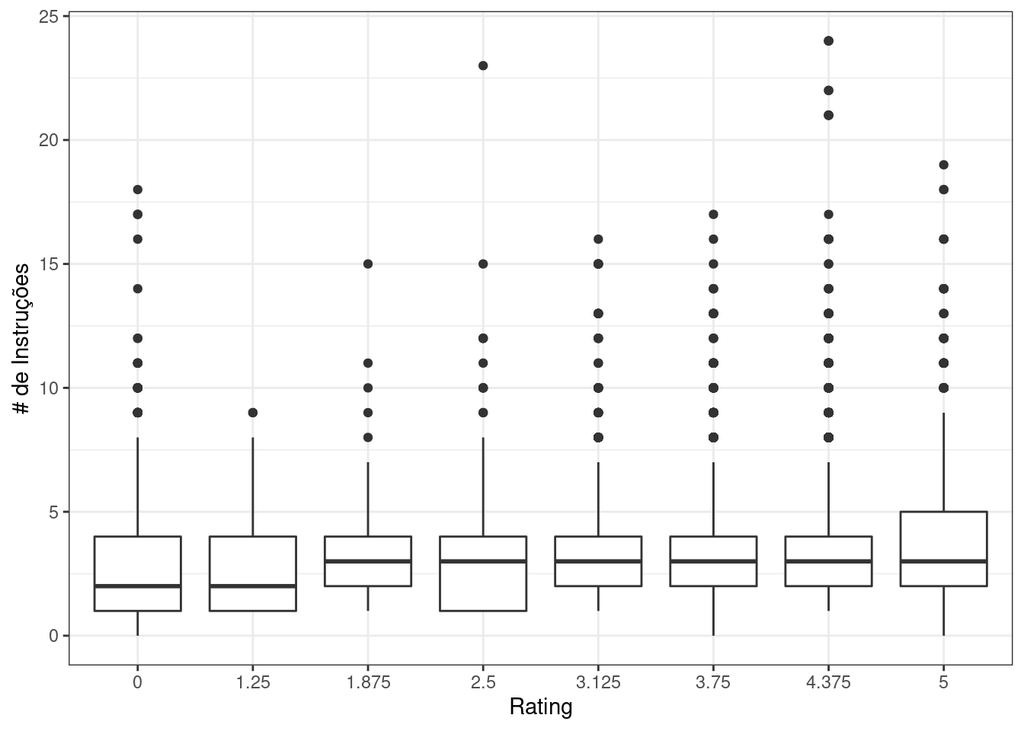

A quantidade de instruções não parece influenciar em grande magnitudes o rating, contudo notamos que há certo impacto sim. Os rating 0, 1 e 2.5, tiveram um baixo número de instruções comparado aos demais. Além de que o rating 5 tem uma tendência maior de conter um número maior de instruções do que demais. O que nos indica de que receitas bem instruídas são em geral melhores do que as aquelas pouco instruídas.

# Pergunta 2: Como se comportam essa variáveis no tempo?

## Rating

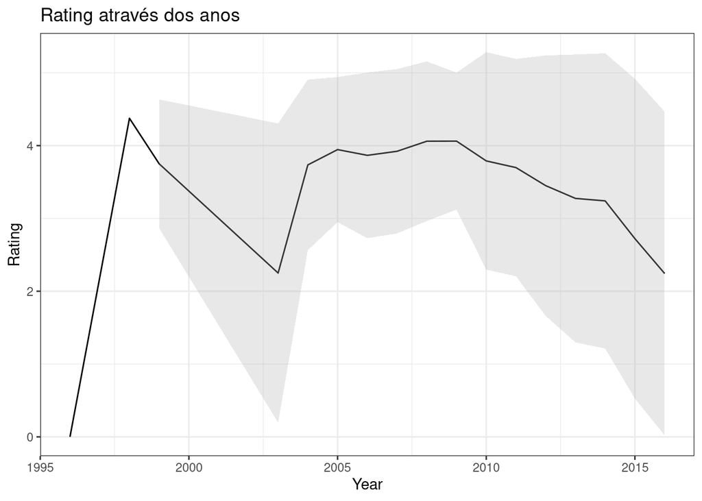

O que podemos concluir com esse gráfico é de que o acréscimo de receita dos últimos tempos tem sido de qualidade questionável. Talvez as pessoas estejam experimentando mais com a culinária o que leva a essa variância maior, porém, abaixa a sua média em geral, com novos pratos que não são apetitosos.

## Quantidade de Receitas

Outro gráfico interessante é vermos a quantidade de receitas no tempo.

[figure not shown]

Vemos que nessa nossa base de dados a maioria das receitas foi adicionada no ano de 2004. Isto é interessante para notarmos que a maioria das nossas análises irá refletir esse período e não a atualidade.

## Fat, sodium, protein, etc..

```
## geom_path: Each group consists of only one observation. Do you need to adjust
## the group aesthetic?
```

[figure not shown]